# Scale Logo

Import Everything

```python
import numpy
from skimage import io
import matplotlib.pyplot as plt
from matplotlib.colors import ListedColormap
```

Load Initial Image

```python
scaleLogo = io.imread('https://findvectorlogo.com/wp-content/uploads/2019/07/scale-ai-inc-vector-logo.png')
```

For fun, separate into different color channels

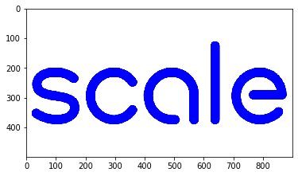

```python
# Make 3d color image by repeating 2d grayscale across 3 dimensions
scaleColor = numpy.repeat(scaleLogo[:, :, numpy.newaxis].copy(), 3, axis=2)

# Make text blue
scaleColor[scaleColor[:,:,2] != 255,2] = 255

# Render image
plt.imshow(scaleColor)
plt.show()
```

# Goal: Take a bw image of the Scale logo and color it

## Attempt 1

Step 1: Extract our letter groupings to get a list of column indices where our letters start and stop, as well as an index for that letter.

```python
# Get Sum of Grayscale Pixels Vertically. If not all white, it's a letter
isLetter = scaleLogo.sum(axis=0) != scaleLogo.shape[0] * 255

# Find Start and End Points Vertically
startPoints = numpy.logical_and(numpy.logical_not(isLetter), numpy.roll(isLetter,-1))
endPoints = numpy.logical_and(numpy.logical_not(isLetter), numpy.roll(isLetter,1))
startStop = numpy.array([
    numpy.argwhere(startPoints)[:,0],
    numpy.argwhere(endPoints)[:,0],
    numpy.arange(1,sum(startPoints)+1)
])
print(startStop)
```

```
[[ 17 200 395 621 692]
 [180 376 584 655 881]
 [  1   2   3   4   5]]
```

The use of *numpy.roll* I found particularly satisfying (until I found numpy.diff that is...)

Once I knew whether each vertical line corresponded to a letter, I had to find the points where the letters started and stopped. Shifting the known coordinates to the left or right 1 pixel and finding where those points are still true allows me to do that.

Step 2: Convert Image to 1s and 0s

```python
# Convert image to just 1s and 0s
scaleLogo[scaleLogo != 255] = 1
scaleLogo[scaleLogo == 255] = 0
```

Step 3: Create a Color Map of the Scale Colors

```python
scaleColors = ListedColormap([
    [0/255,0/255,0/255,1],
    [253/255,157/255,81/255,1],
    [237/255,113/255,147/255,1],
    [221/255,70/255,211/255,1],
    [185/255,65/255,233/255,1],
    [148/255,60/255,255/255,1]
])
```

Step 4: For each letter found in the image, make those pixels have the corresponding value in the StartStop variable

```python
for idx in range(startStop.shape[1]):
    scaleLogo[:, startStop[0,idx]:startStop[1,idx]] = \
        scaleLogo[:, startStop[0,idx]:startStop[1,idx]] * startStop[2,idx]
```

Step 5: Last but not least, render it!

[figure not shown]

```python
plt.imshow(scaleLogo, cmap=scaleColors)
plt.show()
```

## Attempt 2

While the first attempt worked, I really wanted to remove the for loop.

I found a pretty cool function called *interp* that would allow me to dynamically create a mask row vector where I could label each letter with it's own number.

Read in our image

```python
scaleLogo = io.imread('https://findvectorlogo.com/wp-content/uploads/2019/07/scale-ai-inc-vector-logo.png')
```

This time, immediately convert it to a binary 2d array where letters = 1, and everything else = 0

```python
binImage = (scaleLogo[:][:] < 255).astype(int)
```

Now that we have our image, flatten the columns to indicate whether a letter is in that column or not.

1 = Letter in Column, 0 = No Letter

```python
maxBin = numpy.max(binImage,axis=0)
```

Use the *diff* function to find where letters start and stop, then find all the places where letters start specifically.

```python
letterStartIdxs = numpy.argwhere(numpy.diff(maxBin) == 1)[:,0]
```

Now, we're going to do some magic, or well, cool extrapolation

Given a 1d array the width of our image (xx), do a piece-wise extrapolation at our start indexes (xp) to a letter index (fp).

Round all the extrapolated values up so we have a consistent integer corresponding to one letter

```python
xx = numpy.arange(maxBin.size)
xp = letterStartIdxs
fp = numpy.arange(xp.size)
letterMask = numpy.ceil(numpy.interp(xx,xp,fp,0,xp.size))
```

To help you visualize what *letterMask* looks like, you can check out this graph

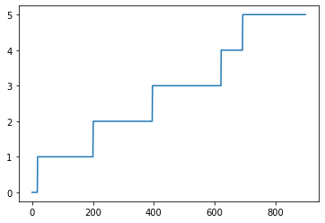

```python
plt.plot(letterMask)
plt.show()
```

Now that we have a handy 1d array indicating what letter each column corresponds with, we can multiply our binary representation of the image by the letter mask, thus labeling every letter with it's corresponding color index.

We'll use the same color map as we did in Attempt1 to specify which color each part of our image should get.

[figure not shown]

```python
colored = binImage[:] * letterMask
plt.imshow(colored, cmap=scaleColors)
plt.show()
```